# Regression

Reference: http://www3.dsi.uminho.pt/pcortez/student.pdf

Past research conducted by comparing three input configurations:  
1. A - with all variables from Table 1 except G3 (the output)  
2. B - similar to A but without G2 (the second period grade)  
3. C - similar to B but without G1 (the first period grade)

Best result is A using naive predictor (NV) and randomForest (RF) with RMSE value = 1.32

# Import Libraries

```r
library(caret)
```

# Load Data

```r
data <- read.csv("../data/student-por_v3.csv", stringsAsFactors = TRUE)
str(data)
```

```
'data.frame':   649 obs. of  34 variables:
 $ school    : Factor w/ 2 levels "GP","MS": 1 1 1 1 1 1 1 1 1 1 ...
 $ sex       : Factor w/ 2 levels "F","M": 1 1 1 1 1 2 2 1 2 2 ...
 $ age       : int  18 17 15 15 16 16 16 17 15 15 ...
 $ address   : Factor w/ 2 levels "R","U": 2 2 2 2 2 2 2 2 2 2 ...
 $ famsize   : Factor w/ 2 levels "GT3","LE3": 1 1 2 1 1 2 2 1 2 1 ...
 $ Pstatus   : Factor w/ 2 levels "A","T": 1 2 2 2 2 2 2 1 1 2 ...
 $ Medu      : int  4 1 1 4 3 4 2 4 3 3 ...
 $ Fedu      : int  4 1 1 2 3 3 2 4 2 4 ...
 $ Mjob      : Factor w/ 5 levels "at_home","health",..: 1 1 1 2 3 4 3 3 4 3 ...
 $ Fjob      : Factor w/ 5 levels "at_home","health",..: 5 3 3 4 3 3 3 5 3 3 ...
 $ reason    : Factor w/ 4 levels "course","home",..: 1 1 3 2 2 4 2 2 2 2 ...
 $ guardian  : Factor w/ 3 levels "father","mother",..: 2 1 2 2 1 2 2 2 2 2 ...
 $ traveltime: int  2 1 1 1 1 1 1 2 1 1 ...
 $ studytime : int  2 2 2 3 2 2 2 2 2 2 ...
```

[output cut: 20 more lines]

```r
summary(data)
```

```
 school   sex          age        address famsize   Pstatus      Medu            Fedu             Mjob           Fjob            reason      guardian
 GP:423   F:383   Min.   :15.00   R:197   GT3:457   A: 80   Min.   :0.000   Min.   :0.000   at_home :135   at_home : 42   course    :285   father:153
 MS:226   M:266   1st Qu.:16.00   U:452   LE3:192   T:569   1st Qu.:2.000   1st Qu.:1.000   health  : 48   health  : 23   home      :149   mother:455
                  Median :17.00                             Median :2.000   Median :2.000   other   :258   other   :367   other     : 72   other : 41
                  Mean   :16.74                             Mean   :2.515   Mean   :2.307   services:136   services:181   reputation:143
                  3rd Qu.:18.00                             3rd Qu.:4.000   3rd Qu.:3.000   teacher : 72   teacher : 36
                  Max.   :22.00                             Max.   :4.000   Max.   :4.000
   traveltime      studytime        failures      schoolsup famsup     paid     activities nursery   higher    internet  romantic      famrel         freetime
 Min.   :1.000   Min.   :1.000   Min.   :0.0000   no :581   no :251   no :610   no :334    no :128   no : 69   no :151   no :410   Min.   :1.000   Min.   :1.00
 1st Qu.:1.000   1st Qu.:1.000   1st Qu.:0.0000   yes: 68   yes:398   yes: 39   yes:315    yes:521   yes:580   yes:498   yes:239   1st Qu.:4.000   1st Qu.:3.00
 Median :1.000   Median :2.000   Median :0.0000                                                                                    Median :4.000   Median :3.00
 Mean   :1.569   Mean   :1.931   Mean   :0.2219                                                                                    Mean   :3.931   Mean   :3.18
 3rd Qu.:2.000   3rd Qu.:2.000   3rd Qu.:0.0000                                                                                    3rd Qu.:5.000   3rd Qu.:4.00
 Max.   :4.000   Max.   :4.000   Max.   :3.0000                                                                                    Max.   :5.000   Max.   :5.00
     goout            Dalc            Walc          health         absences            G1             G2              G3         result
 Min.   :1.000   Min.   :1.000   Min.   :1.00   Min.   :1.000   Min.   : 0.000   Min.   : 0.0   Min.   : 0.00   Min.   : 0.00   fail:100
 1st Qu.:2.000   1st Qu.:1.000   1st Qu.:1.00   1st Qu.:2.000   1st Qu.: 0.000   1st Qu.:10.0   1st Qu.:10.00   1st Qu.:10.00   pass:549
 Median :3.000   Median :1.000   Median :2.00   Median :4.000   Median : 2.000   Median :11.0   Median :11.00   Median :12.00
 Mean   :3.185   Mean   :1.502   Mean   :2.28   Mean   :3.536   Mean   : 3.659   Mean   :11.4   Mean   :11.57   Mean   :11.91
 3rd Qu.:4.000   3rd Qu.:2.000   3rd Qu.:3.00   3rd Qu.:5.000   3rd Qu.: 6.000   3rd Qu.:13.0   3rd Qu.:13.00   3rd Qu.:14.00
 Max.   :5.000   Max.   :5.000   Max.   :5.00   Max.   :5.000   Max.   :32.000   Max.   :19.0   Max.   :19.00   Max.   :19.00
```

# Drop Columns

```r
data <- subset(data, select = -result)
str(data)
```

```
'data.frame':   649 obs. of  33 variables:
 $ school    : Factor w/ 2 levels "GP","MS": 1 1 1 1 1 1 1 1 1 1 ...
 $ sex       : Factor w/ 2 levels "F","M": 1 1 1 1 1 2 2 1 2 2 ...
 $ age       : int  18 17 15 15 16 16 16 17 15 15 ...
 $ address   : Factor w/ 2 levels "R","U": 2 2 2 2 2 2 2 2 2 2 ...
 $ famsize   : Factor w/ 2 levels "GT3","LE3": 1 1 2 1 1 2 2 1 2 1 ...
 $ Pstatus   : Factor w/ 2 levels "A","T": 1 2 2 2 2 2 2 1 1 2 ...
 $ Medu      : int  4 1 1 4 3 4 2 4 3 3 ...
 $ Fedu      : int  4 1 1 2 3 3 2 4 2 4 ...
 $ Mjob      : Factor w/ 5 levels "at_home","health",..: 1 1 1 2 3 4 3 3 4 3 ...
 $ Fjob      : Factor w/ 5 levels "at_home","health",..: 5 3 3 4 3 3 3 5 3 3 ...
 $ reason    : Factor w/ 4 levels "course","home",..: 1 1 3 2 2 4 2 2 2 2 ...
 $ guardian  : Factor w/ 3 levels "father","mother",..: 2 1 2 2 1 2 2 2 2 2 ...
 $ traveltime: int  2 1 1 1 1 1 1 2 1 1 ...
 $ studytime : int  2 2 2 3 2 2 2 2 2 2 ...
```

[output cut: 19 more lines]

```r
summary(data)
```

```
 school   sex          age        address famsize   Pstatus      Medu            Fedu             Mjob           Fjob            reason      guardian
 GP:423   F:383   Min.   :15.00   R:197   GT3:457   A: 80   Min.   :0.000   Min.   :0.000   at_home :135   at_home : 42   course    :285   father:153
 MS:226   M:266   1st Qu.:16.00   U:452   LE3:192   T:569   1st Qu.:2.000   1st Qu.:1.000   health  : 48   health  : 23   home      :149   mother:455
                  Median :17.00                             Median :2.000   Median :2.000   other   :258   other   :367   other     : 72   other : 41
                  Mean   :16.74                             Mean   :2.515   Mean   :2.307   services:136   services:181   reputation:143
                  3rd Qu.:18.00                             3rd Qu.:4.000   3rd Qu.:3.000   teacher : 72   teacher : 36
                  Max.   :22.00                             Max.   :4.000   Max.   :4.000
   traveltime      studytime        failures      schoolsup famsup     paid     activities nursery   higher    internet  romantic      famrel         freetime
 Min.   :1.000   Min.   :1.000   Min.   :0.0000   no :581   no :251   no :610   no :334    no :128   no : 69   no :151   no :410   Min.   :1.000   Min.   :1.00
 1st Qu.:1.000   1st Qu.:1.000   1st Qu.:0.0000   yes: 68   yes:398   yes: 39   yes:315    yes:521   yes:580   yes:498   yes:239   1st Qu.:4.000   1st Qu.:3.00
 Median :1.000   Median :2.000   Median :0.0000                                                                                    Median :4.000   Median :3.00
 Mean   :1.569   Mean   :1.931   Mean   :0.2219                                                                                    Mean   :3.931   Mean   :3.18
 3rd Qu.:2.000   3rd Qu.:2.000   3rd Qu.:0.0000                                                                                    3rd Qu.:5.000   3rd Qu.:4.00
 Max.   :4.000   Max.   :4.000   Max.   :3.0000                                                                                    Max.   :5.000   Max.   :5.00
     goout            Dalc            Walc          health         absences            G1             G2              G3
 Min.   :1.000   Min.   :1.000   Min.   :1.00   Min.   :1.000   Min.   : 0.000   Min.   : 0.0   Min.   : 0.00   Min.   : 0.00
 1st Qu.:2.000   1st Qu.:1.000   1st Qu.:1.00   1st Qu.:2.000   1st Qu.: 0.000   1st Qu.:10.0   1st Qu.:10.00   1st Qu.:10.00
 Median :3.000   Median :1.000   Median :2.00   Median :4.000   Median : 2.000   Median :11.0   Median :11.00   Median :12.00
 Mean   :3.185   Mean   :1.502   Mean   :2.28   Mean   :3.536   Mean   : 3.659   Mean   :11.4   Mean   :11.57   Mean   :11.91
 3rd Qu.:4.000   3rd Qu.:2.000   3rd Qu.:3.00   3rd Qu.:5.000   3rd Qu.: 6.000   3rd Qu.:13.0   3rd Qu.:13.00   3rd Qu.:14.00
 Max.   :5.000   Max.   :5.000   Max.   :5.00   Max.   :5.000   Max.   :32.000   Max.   :19.0   Max.   :19.00   Max.   :19.00
```

# Convert Columns to Factor

```r
col_names <- setdiff(colnames(data), c("age","absences","G1","G2","G3"))

data[col_names] <- lapply(data[col_names] , factor)
str(data)
```

```
'data.frame':   649 obs. of  33 variables:
 $ school    : Factor w/ 2 levels "GP","MS": 1 1 1 1 1 1 1 1 1 1 ...
 $ sex       : Factor w/ 2 levels "F","M": 1 1 1 1 1 2 2 1 2 2 ...
 $ age       : int  18 17 15 15 16 16 16 17 15 15 ...
 $ address   : Factor w/ 2 levels "R","U": 2 2 2 2 2 2 2 2 2 2 ...
 $ famsize   : Factor w/ 2 levels "GT3","LE3": 1 1 2 1 1 2 2 1 2 1 ...
 $ Pstatus   : Factor w/ 2 levels "A","T": 1 2 2 2 2 2 2 1 1 2 ...
 $ Medu      : Factor w/ 5 levels "0","1","2","3",..: 5 2 2 5 4 5 3 5 4 4 ...
 $ Fedu      : Factor w/ 5 levels "0","1","2","3",..: 5 2 2 3 4 4 3 5 3 5 ...
 $ Mjob      : Factor w/ 5 levels "at_home","health",..: 1 1 1 2 3 4 3 3 4 3 ...
 $ Fjob      : Factor w/ 5 levels "at_home","health",..: 5 3 3 4 3 3 3 5 3 3 ...
 $ reason    : Factor w/ 4 levels "course","home",..: 1 1 3 2 2 4 2 2 2 2 ...
 $ guardian  : Factor w/ 3 levels "father","mother",..: 2 1 2 2 1 2 2 2 2 2 ...
 $ traveltime: Factor w/ 4 levels "1","2","3","4": 2 1 1 1 1 1 1 2 1 1 ...
 $ studytime : Factor w/ 4 levels "1","2","3","4": 2 2 2 3 2 2 2 2 2 2 ...
```

[output cut: 19 more lines]

```r
summary(data)
```

```
 school   sex          age        address famsize   Pstatus Medu    Fedu          Mjob           Fjob            reason      guardian   traveltime studytime failures
 GP:423   F:383   Min.   :15.00   R:197   GT3:457   A: 80   0:  6   0:  7   at_home :135   at_home : 42   course    :285   father:153   1:366      1:212     0:549
 MS:226   M:266   1st Qu.:16.00   U:452   LE3:192   T:569   1:143   1:174   health  : 48   health  : 23   home      :149   mother:455   2:213      2:305     1: 70
                  Median :17.00                             2:186   2:209   other   :258   other   :367   other     : 72   other : 41   3: 54      3: 97     2: 16
                  Mean   :16.74                             3:139   3:131   services:136   services:181   reputation:143                4: 16      4: 35     3: 14
                  3rd Qu.:18.00                             4:175   4:128   teacher : 72   teacher : 36
                  Max.   :22.00
 schoolsup famsup     paid     activities nursery   higher    internet  romantic  famrel  freetime goout   Dalc    Walc    health     absences            G1
 no :581   no :251   no :610   no :334    no :128   no : 69   no :151   no :410   1: 22   1: 45    1: 48   1:451   1:247   1: 90   Min.   : 0.000   Min.   : 0.0
 yes: 68   yes:398   yes: 39   yes:315    yes:521   yes:580   yes:498   yes:239   2: 29   2:107    2:145   2:121   2:150   2: 78   1st Qu.: 0.000   1st Qu.:10.0
                                                                                  3:101   3:251    3:205   3: 43   3:120   3:124   Median : 2.000   Median :11.0
                                                                                  4:317   4:178    4:141   4: 17   4: 87   4:108   Mean   : 3.659   Mean   :11.4
                                                                                  5:180   5: 68    5:110   5: 17   5: 45   5:249   3rd Qu.: 6.000   3rd Qu.:13.0
                                                                                                                                   Max.   :32.000   Max.   :19.0
       G2              G3
 Min.   : 0.00   Min.   : 0.00
 1st Qu.:10.00   1st Qu.:10.00
 Median :11.00   Median :12.00
 Mean   :11.57   Mean   :11.91
 3rd Qu.:13.00   3rd Qu.:14.00
 Max.   :19.00   Max.   :19.00
```

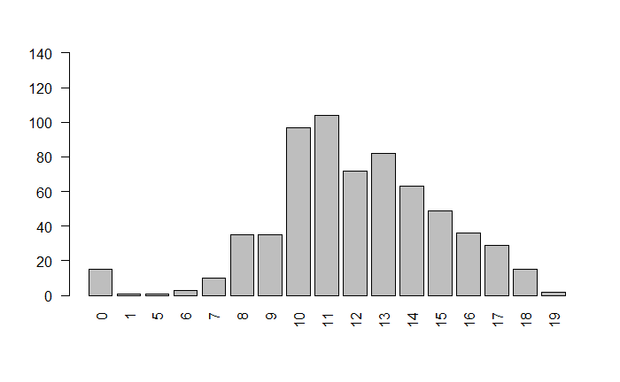

```r
barplot(table(data$G3), ylim=c(0,150), las = 2)
```

# Train-Test Split

```r
set.seed(42)

train_index <- createDataPartition(
  data$G3,
  p = 0.8,
  list = FALSE,
  times = 1
)

train_set <- data[train_index, ]
test_set <- data[-train_index, ]
```

```r
nrow(train_set)
```

```
[1] 520
```

```r
nrow(test_set)
```

```
[1] 129
```

# Modelling

### Set 10-fold CV

```r
set.seed(42)

fit_control <- trainControl(
  method = "repeatedcv",
  number = 10,
  repeats = 10
)
```

```r
get_best_result = function(caret_fit) {
  best = which(rownames(caret_fit$results) == rownames(caret_fit$bestTune))
  best_result = caret_fit$results[best, ]
  rownames(best_result) = NULL
  best_result
  #getTrainPerf(caret_fit)
}
```

## 1. Decision Tree

CART

- method = ‘rpart’
- Type: Regression, Classification
- Tuning parameters:
  - cp (Complexity Parameter)
- Required packages: rpart
- A model-specific variable importance metric is available.

### Training model with auto tuning

```r
dt_fit <- train(
  G3 ~ .,
  data = train_set,
  method = "rpart",
  trControl = fit_control,
  preProcess = c("center", "scale")
)
# warning message above is just a warning about some parameters that do very poorly so that the RMSE is a little worse than the basic st deviation of the outcome
# Reference: https://github.com/topepo/caret/issues/905

dt_fit
```

```
CART

520 samples
 32 predictor

Pre-processing: centered (71), scaled (71)
Resampling: Cross-Validated (10 fold, repeated 10 times)
Summary of sample sizes: 469, 468, 467, 467, 469, 470, ...
Resampling results across tuning parameters:

  cp          RMSE      Rsquared   MAE
  0.09192435  1.906296  0.6688216  1.316759
  0.12758253  2.187026  0.5664101  1.541710
  0.52269634  2.783265  0.4885543  2.047430

RMSE was used to select the optimal model using the smallest value.
The final value used for the model was cp = 0.09192435.
```

### Training result

```r
get_best_result(dt_fit)
```

| cp | RMSE | Rsquared | MAE | RMSESD | RsquaredSD | MAESD |
| --- | --- | --- | --- | --- | --- | --- |
| 0.09192435 | 1.906296 | 0.6688216 | 1.316759 | 0.3434533 | 0.08424464 | 0.220545 |

### Plot the trained model

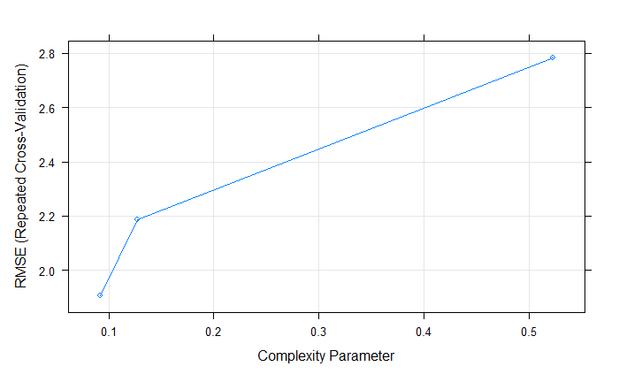

```r
plot(dt_fit)
```

Value 0.09 is not the optimal value for complexity parameter, hence the parameter should be tuned with value < 0.09.

### Predict G3 from test data

```r
dt_pred <- predict(dt_fit, test_set)
```

### Evaluation

```r
postResample(pred = dt_pred, obs = test_set$G3)
```

```
    RMSE Rsquared      MAE
1.735002 0.672753 1.322848
```

The performance of model can be improved compared to model from past research where RMSE value = 1.32

### Training model with manual tuning

- cp (Complexity Parameter) = 0.01 or 0.005 or 0.001

```r
tuneGrid <- expand.grid(
  cp = c(0.01, 0.005, 0.001)
)

dt_fit <- train(
  G3 ~ .,
  data = train_set,
  method = "rpart",
  trControl = fit_control,
  preProcess = c("center", "scale"),
  tuneGrid = tuneGrid
)

dt_fit
```

```
CART

520 samples
 32 predictor

Pre-processing: centered (71), scaled (71)
Resampling: Cross-Validated (10 fold, repeated 10 times)
Summary of sample sizes: 467, 468, 467, 469, 469, 467, ...
Resampling results across tuning parameters:

  cp     RMSE      Rsquared   MAE
  0.001  1.452716  0.8082852  0.9007976
  0.005  1.417917  0.8178747  0.8360895
  0.010  1.435017  0.8129989  0.8489929

RMSE was used to select the optimal model using the smallest value.
The final value used for the model was cp = 0.005.
```

### Training result after manual tuning

```r
get_best_result(dt_fit)
```

| cp | RMSE | Rsquared | MAE | RMSESD | RsquaredSD | MAESD |
| --- | --- | --- | --- | --- | --- | --- |
| 0.005 | 1.417917 | 0.8178747 | 0.8360895 | 0.3988714 | 0.07770059 | 0.165541 |

### Plot the trained model after manual tuning

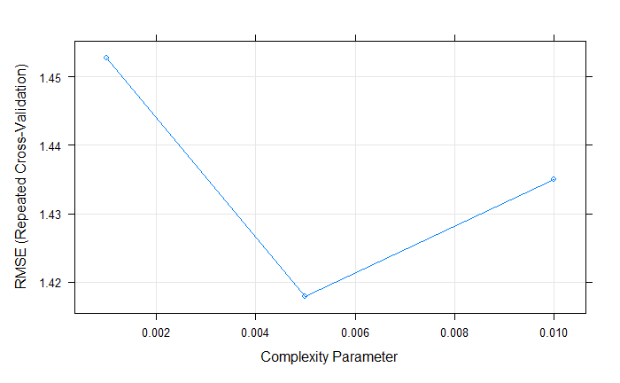

```r
plot(dt_fit)
```

Value 0.005 is the optimal value for complexity parameter.

### Predict G3 from test data using the manually tuned model

```r
dt_pred <- predict(dt_fit, test_set)
```

### Evaluation of the manually tuned model

```r
postResample(pred = dt_pred, obs = test_set$G3)
```

```
     RMSE  Rsquared       MAE
1.3407463 0.8114244 0.8614620
```

The performance of model has improved significantly from RMSE of 1.74 to 1.34 although it did not perform better than model from past research where RMSE value = 1.32.

## 2. Random Forest

Random Forest

- method = ‘ranger’
- Type: Classification, Regression
- Tuning parameters:
  - mtry (#Randomly Selected Predictors) (Number of variables randomly sampled as candidates at each split.)
  - splitrule (Splitting Rule)
  - min.node.size (Minimal Node Size)
- Required packages: e1071, ranger, dplyr
- A model-specific variable importance metric is available.

### Training model with auto tuning

```r
rf_fit <- train(
  G3 ~ .,
  data = train_set,
  method = "ranger",
  trControl = fit_control,
  preProcess = c("center", "scale")
)
```

### Training result

```r
get_best_result(rf_fit)
```

| mtry | min.node.size | splitrule | RMSE | Rsquared | MAE | RMSESD | RsquaredSD | MAESD |
| --- | --- | --- | --- | --- | --- | --- | --- | --- |
| 36 | 5 | variance | 1.305939 | 0.8426474 | 0.8341949 | 0.3541653 | 0.0697407 | 0.1326514 |

### Plot the trained model

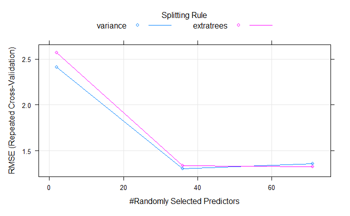

```r
plot(rf_fit)
```

- For splitrule (splitting rule) = variance, mtry = 36 is already the optimal value.
- For splitrule (splitting rule) = extratrees, can try to tune with mtry > 70 to optimize the model’s performance.
- Tuning parameter ‘min.node.size’ was held constant at a value of 5, can try to tune with other values.

### Predict G3 from test data

```r
rf_pred <- predict(rf_fit, test_set)
```

### Evaluation

```r
postResample(pred = rf_pred, obs = test_set$G3)
```

```
     RMSE  Rsquared       MAE
1.1000630 0.8682354 0.7915594
```

- The Random Forest model is performed a lot better compared to model from past research where RMSE value = 1.32.
- We can still try to tune the parameters manually to optimize the model’s performance.

### Training model with manual tuning

- mtry (#Randomly Selected Predictors)
- splitrule (Splitting Rule)
- min.node.size (Minimal Node Size)

```r
tuneGrid <- expand.grid(
  mtry = c(36, 70, 80),
  splitrule = c("variance", "extratrees"),
  min.node.size = c(2,5,8)
)

rf_fit <- train(
  G3 ~ .,
  data = train_set,
  method = "ranger",
  trControl = fit_control,
  preProcess = c("center", "scale"),
  tuneGrid = tuneGrid
)

rf_fit

#Error: mtry can not be larger than number of variables in data. Ranger will EXIT now.
#Warning: model fit failed for Fold07.Rep02: mtry=80, splitrule=extratrees, min.node.size=5 Error in ranger::ranger(dependent.variable.name = ".outcome", data = x,  :
#  User interrupt or internal error.
```

[output not shown]

### Training result after manual tuning

```r
get_best_result(rf_fit)
```

| mtry | splitrule | min.node.size | RMSE | Rsquared | MAE | RMSESD | RsquaredSD | MAESD |
| --- | --- | --- | --- | --- | --- | --- | --- | --- |
| 36 | variance | 8 | 1.306599 | 0.8452846 | 0.8319969 | 0.3325063 | 0.06309004 | 0.1157421 |

### Plot the trained model after manual tuning

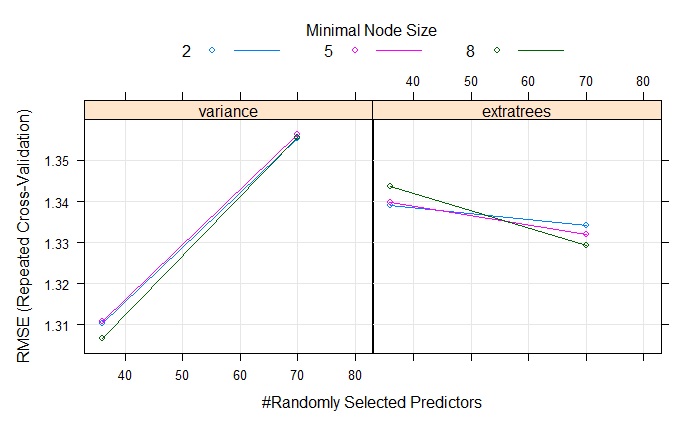

```r
plot(rf_fit)
```

- Parameter mtry cannot be 80 hence the maximum mtry seems to be 71. (Not sure how to calculate maximum mtry)
- For splitrule = extratrees, the result is not as good as splitrule = variance. So we will stop the optimization using splitrule = extratrees at this point.
- For splitrule = variance, we can try to tune with minimal node size > 8 and mtry < 36.

```r
tuneGrid <- expand.grid(
  mtry = seq(30,36,by=2),
  splitrule = c("variance"),
  min.node.size = seq(5,10,by=1)
)

rf_fit <- train(
  G3 ~ .,
  data = train_set,
  method = "ranger",
  trControl = fit_control,
  preProcess = c("center", "scale"),
  tuneGrid = tuneGrid
)
```

### Training result after manual tuning

```r
get_best_result(rf_fit)
```

| mtry | splitrule | min.node.size | RMSE | Rsquared | MAE | RMSESD | RsquaredSD | MAESD |
| --- | --- | --- | --- | --- | --- | --- | --- | --- |
| 36 | variance | 7 | 1.305934 | 0.8443919 | 0.8334334 | 0.3559243 | 0.06698815 | 0.1360248 |

### Plot the trained model after manual tuning

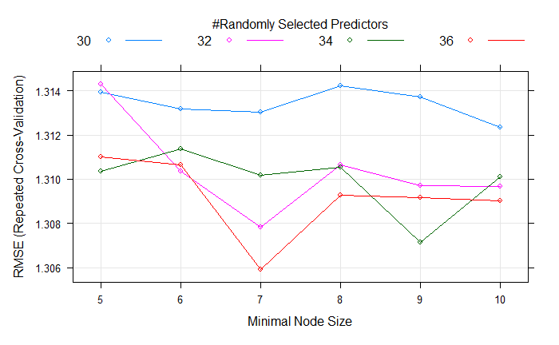

```r
plot(rf_fit)
```

- Optimal values:
  - minial node size = 7
  - mtry = 36
  - splitting rule = variance

### Predict G3 from test data using manually tuned model

```r
rf_pred <- predict(rf_fit, test_set)
```

### Evaluation of manually tuned model

```r
postResample(pred = rf_pred, obs = test_set$G3)
```

```
     RMSE  Rsquared       MAE
1.0963125 0.8692666 0.7821115
```

Slight improvement of the model’s performance from RMSE of 1.100 to 1.096 compared to auto tuned model.